# EasyAovWlxPlot

Liu Yong-Xin

2020/2/14

## 写在前面

最初这份脚本是这样的：[R语言一键批量完成差异统计和可视化](https://mp.weixin.qq.com/s/IGrj81ZzfEF8aXYIMhBh7A)。当时我们发布的版本，我封装的比较简单，每个步骤不能分开跑，只能按照流程从一而终，后来我做[升级版：查看升级版本](https://mp.weixin.qq.com/s/2_4cTHnP8ojzKzjxbAbYxw)，将多重比较方法和可视化进行了丰富，再后来我发现正态分布函数错误，所以又进行了[更正：查看更正版本](https://mp.weixin.qq.com/s/SuJEyiY1nRVui6BlbYLsuQ)，最后就是咱们这篇教程了。

作为宏基因组副主编，我觉得有责任将这件事情做到底。过于厚实的封装让大家无法体会到每个步骤的输入输出，所以我将整体部分分为了多个步骤，按照**数据检验–统计分析–图表展示，这三个步骤**来做，思路清晰，一目了然。将这套统计分析整理成了多个函数，提供每个模块的操作，同时又可以一体化实现统计分析，错误也修改了，大家各种需求我也添加了，所以这个R包就到可以写的时候了，前几天我完成了这个事情。目前已经可以安装了。也欢迎大家到我的GitHub上访问，说来惭愧，目前有几个都是不成熟的项目。

下面这张建议的图形我在ppt里面做的，希望可以让大家明白这个R包的思路。下面我就要开始介绍这个R包的功能啦。

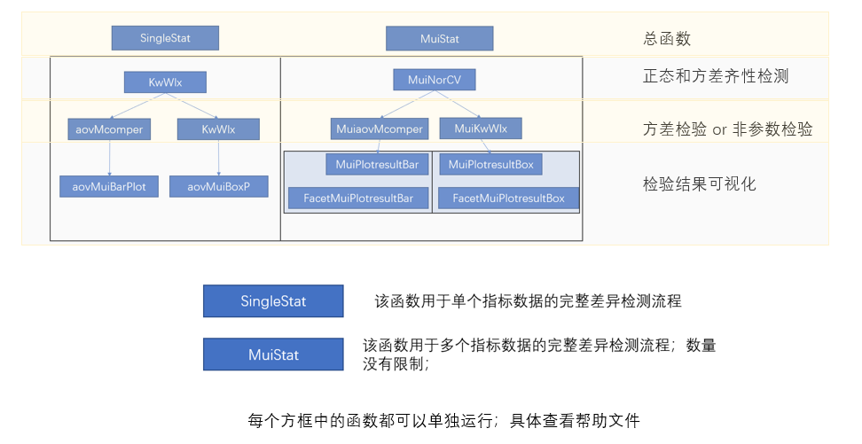

图0

## EasyAovWlxPlot 使用指南

### 安装EasyAovWlxPlot包

安装包我已经在两台win10上测试过并且在ubuuntu服务器上也可以正常安装，希望大家也安装顺利。

```r
library(devtools)
```

```r
# install_github("taowenmicro/EasyAovWlxPlot")
```

### 导入包

```r
library(EasyAovWlxPlot)
library(ggplot2)
#使用内置数据
data(data_wt)
```

内置数据集介绍： 这是四个处理的土壤的化学性质指标测定的结果，前两列分别是样本名称，分组信息，第3列到第12列是不同指标

```
 ID group    AK        AP      bac    fun   micro   NH4-N   NO3-N    pH      SOM       TN
1   CF1    CF 303.6  77.82301 12000000  72000 1668000  9.6432 70.0112 9.216 29.04867 5.076147
2   CF2    CF 298.8  73.97303 14400000  36000 1500000  9.7314 71.6282 8.340 28.46617 5.013429
3   CF3    CF 294.0  91.16963 10800000  36000  648000  9.2022 90.1894 8.604 28.48510 5.244267
4   CK1    CK 242.4 112.72954 30000000  84000 1788000  9.9960 79.3604 3.600  5.11066 4.969990
5   CK2    CK 273.6  94.07850 26400000  48000  720000  9.7902 82.2220 3.720 24.68137 4.812697
6   CK3    CK 270.0 102.80513  7200000  48000  996000  9.6726 79.8602 3.720 25.07207 4.843911
7  Rhi1   Rhi 330.0  91.25518 33600000 264000 2628000  9.4668 56.0756 9.108 34.30180 6.058957
8  Rhi2   Rhi 343.2  92.88073 39600000 240000 2112000 10.0548 55.6052 9.372 33.37313 5.927957
9  Rhi3   Rhi 344.4  87.49075 30000000 228000 2520000  9.6432 55.4386 8.784 31.50144 5.227732
10  WT1    WT 338.4  90.57074 19200000  60000 1572000 10.0254 73.4412 8.676 31.00468 5.216963
11  WT2    WT 356.4 101.17958 18000000  36000 1584000  9.1728 91.3262 8.604 32.59705 5.543280
12  WT3    WT 360.0  92.45295 14400000  36000 1284000  9.0552 93.6782 7.980 32.01826 5.279473
```

### 基于单个指标的统计分析

#### 正态检验和方差齐性分析NorNorCVTest

```r
?NorNorCVTest
```

```
## starting httpd help server ... done
```

```r
##使用案例
NorCV = NorNorCVTest(data = data_wt, i= 4, method_cv = "leveneTest")
#提取正态检验结果
NorCV[[1]]
```

```
##             No         Name         W   p.value norm.test
## 1            1           CF 0.9077245 0.4105296      Norm
## 2            2           CK 0.9986271 0.9292195      Norm
## 3            3          Rhi 0.9501277 0.5698609      Norm
## 4            4           WT 0.8781602 0.3190147      Norm
## 5 Test Method: Shapiro-Wilk        NA        NA      <NA>
```

```r
#提取方差齐性检验结果
NorCV[[2]]
```

```
## [1] 0.6944591
```

正态检验结果：这里一共有五行，前四行是每个处理的正态检验结果，最后一列标记了是否符合正态分布，显然这里四个组数据都符合正态分布。

```
            No         Name         W   p.value norm.test
1            1           CF 0.9077245 0.4105296      Norm
2            2           CK 0.9986271 0.9292195      Norm
3            3          Rhi 0.9501277 0.5698609      Norm
4            4           WT 0.8781602 0.3190147      Norm
5 Test Method: Shapiro-Wilk        NA        NA      <NA>
```

方差齐性结果，大于0.05，表明符合方差齐性

```
[1] 0.6944591
```